# C3하지혜_빅데이터분석기초2일차

## 192페이지 실습

```python
import pandas as pd
import numpy as np
import matplotlib
import matplotlib.pyplot as plt
import seaborn as sns
```

```python
matplotlib.rc('font', family='NanumGothic')
matplotlib.rcParams['axes.unicode_minus'] = False
plt.rcParams["font.family"] = 'NanumGothic'
```

```python
df = pd.read_csv('Data/titanic.csv', encoding='euc-kr')
df.head()
```

|  | PassengerId | Survived | Pclass | Name | Sex | Age | SibSp | Parch | Ticket | Fare | Cabin | Embarked |
| --- | --- | --- | --- | --- | --- | --- | --- | --- | --- | --- | --- | --- |
| 0 | 1 | 0 | 3 | Braund, Mr. Owen Harris | male | 22.0 | 1 | 0 | A/5 21171 | 7.2500 | NaN | S |
| 1 | 2 | 1 | 1 | Cumings, Mrs. John Bradley (Florence Briggs Th... | female | 38.0 | 1 | 0 | PC 17599 | 71.2833 | C85 | C |
| 2 | 3 | 1 | 3 | Heikkinen, Miss. Laina | female | 26.0 | 0 | 0 | STON/O2. 3101282 | 7.9250 | NaN | S |
| 3 | 4 | 1 | 1 | Futrelle, Mrs. Jacques Heath (Lily May Peel) | female | 35.0 | 1 | 0 | 113803 | 53.1000 | C123 | S |
| 4 | 5 | 0 | 3 | Allen, Mr. William Henry | male | 35.0 | 0 | 0 | 373450 | 8.0500 | NaN | S |

### 기술통계량 확인

```python
df.describe()
```

|  | PassengerId | Survived | Pclass | Age | SibSp | Parch | Fare |
| --- | --- | --- | --- | --- | --- | --- | --- |
| count | 891.000000 | 891.000000 | 891.000000 | 891.000000 | 891.000000 | 891.000000 | 891.000000 |
| mean | 446.000000 | 0.383838 | 2.308642 | 29.758889 | 0.523008 | 0.381594 | 32.204208 |
| std | 257.353842 | 0.486592 | 0.836071 | 13.002570 | 1.102743 | 0.806057 | 49.693429 |
| min | 1.000000 | 0.000000 | 1.000000 | 0.420000 | 0.000000 | 0.000000 | 0.000000 |
| 25% | 223.500000 | 0.000000 | 2.000000 | 22.000000 | 0.000000 | 0.000000 | 7.910400 |
| 50% | 446.000000 | 0.000000 | 3.000000 | 30.000000 | 0.000000 | 0.000000 | 14.454200 |
| 75% | 668.500000 | 1.000000 | 3.000000 | 35.000000 | 1.000000 | 0.000000 | 31.000000 |
| max | 891.000000 | 1.000000 | 3.000000 | 80.000000 | 8.000000 | 6.000000 | 512.329200 |

### 데이터 속성 확인

```python
df.info()  # Cabin 데이터가 null 값이 많이 존재한다.
```

```
<class 'pandas.core.frame.DataFrame'>
RangeIndex: 891 entries, 0 to 890
Data columns (total 12 columns):
 #   Column       Non-Null Count  Dtype
---  ------       --------------  -----
 0   PassengerId  891 non-null    int64
 1   Survived     891 non-null    int64
 2   Pclass       891 non-null    int64
 3   Name         891 non-null    object
 4   Sex          891 non-null    object
 5   Age          891 non-null    float64
 6   SibSp        891 non-null    int64
 7   Parch        891 non-null    int64
 8   Ticket       891 non-null    object
 9   Fare         891 non-null    float64
 10  Cabin        204 non-null    object
 11  Embarked     889 non-null    object
dtypes: float64(2), int64(5), object(5)
memory usage: 83.7+ KB
```

### 목표변수 및 설명변수의 분포 확인

#### 목표변수의 분포 확인

-> 사망: 0, 생존: 1

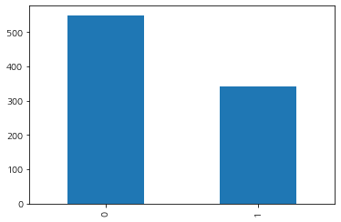

```python
df['Survived'].value_counts().plot.bar()
```

#### 설명변수의 분포 확인

-> Name, Cabin은 분석시 제외하는 것이 낫다고 판단된다.

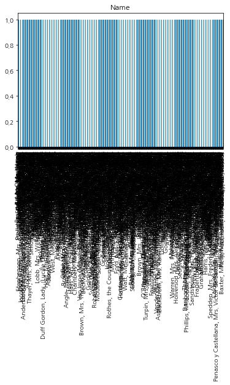

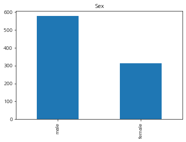

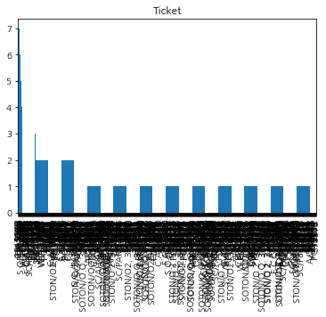

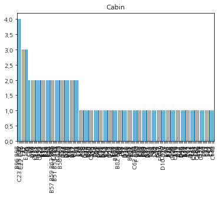

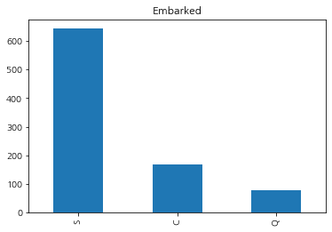

```python
# 범주형 변수(Name, Sex, Ticket, Cabin, Embarked)
df_categorical = ['Name','Sex', 'Ticket', 'Cabin', 'Embarked']
for categorical in df_categorical:
    df[categorical].value_counts().plot(kind='bar')
    plt.title(categorical)
    plt.show()
```

```
array([[<AxesSubplot:title={'center':'PassengerId'}>,
        <AxesSubplot:title={'center':'Survived'}>,
        <AxesSubplot:title={'center':'Pclass'}>],
       [<AxesSubplot:title={'center':'Age'}>,
        <AxesSubplot:title={'center':'SibSp'}>,
        <AxesSubplot:title={'center':'Parch'}>],
       [<AxesSubplot:title={'center':'Fare'}>, <AxesSubplot:>,
        <AxesSubplot:>]], dtype=object)
```

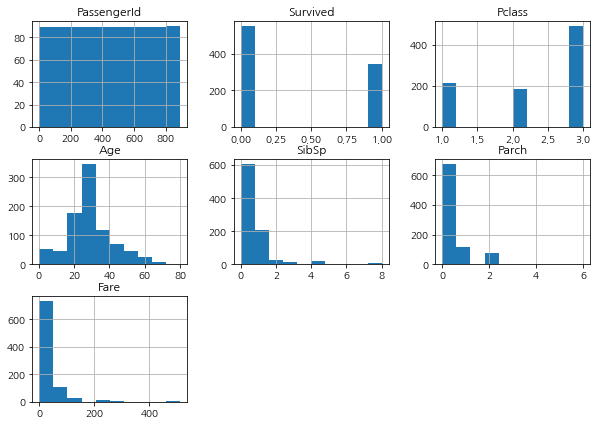

```python
# 연속형 변수(Survived, Pclass, Age, SibSp, Parch, Fare)
df.hist(figsize=(10,7))
```

## 변수들의 결측 및 이상치 처리

```python
# PassengerId는 사용하지 않을 것이므로 drop한다.
df = df.drop(['PassengerId'], axis=1)
df.info()
```

```
<class 'pandas.core.frame.DataFrame'>
RangeIndex: 891 entries, 0 to 890
Data columns (total 11 columns):
 #   Column    Non-Null Count  Dtype
---  ------    --------------  -----
 0   Survived  891 non-null    int64
 1   Pclass    891 non-null    int64
 2   Name      891 non-null    object
 3   Sex       891 non-null    object
 4   Age       891 non-null    float64
 5   SibSp     891 non-null    int64
 6   Parch     891 non-null    int64
 7   Ticket    891 non-null    object
 8   Fare      891 non-null    float64
 9   Cabin     204 non-null    object
 10  Embarked  889 non-null    object
dtypes: float64(2), int64(4), object(5)
memory usage: 76.7+ KB
```

```python
df.isnull().sum()    # Cabin의 null 값: 687개, Embarked의 null 값: 2개
```

[output not shown]

### Cabin의 결측치가 많으므로 drop한다.

```python
df = df.drop(['Cabin'], axis=1)
```

```python
df.isnull().sum()
```

```
Survived    0
Pclass      0
Name        0
Sex         0
Age         0
SibSp       0
Parch       0
Ticket      0
Fare        0
Embarked    2
dtype: int64
```

### 'S'가 가장 많기 때문에 Embarked의 결측치를 'S'로 바꿔준다.

```python
df['Embarked'].value_counts().sort_index()
```

```
C    168
Q     77
S    644
Name: Embarked, dtype: int64
```

```python
df['Embarked'] = df['Embarked'].fillna('S')
```

```python
df['Embarked'].value_counts().sort_index()
```

```
C    168
Q     77
S    646
Name: Embarked, dtype: int64
```

## 변수간 관계

#### 1) Pclass와 Survived의 관계

-> 3등석에서 1등석으로 갈수록 생존한 사람이 많다.

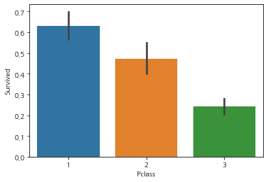

```python
sns.barplot(x="Pclass", y="Survived", data=df)
```

#### 2) Sex와 Survived의 관계

-> 남성보다 여성이 생존한 사람이 많다.

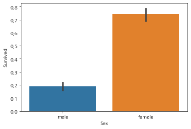

```python
sns.barplot(x="Sex", y="Survived", data=df)
```

#### 3) SibSp와 Survived의 관계

-> 함께 탑승한 형제, 배우자의 수가 1명인 사람이 가장 많이 생존하였다.

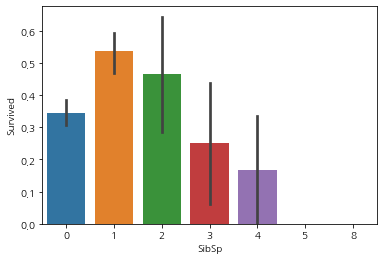

```python
sns.barplot(x="SibSp", y="Survived", data=df)
```

#### 4) Parch와 Survived의 관계

-> 함께 탑승한 자녀, 부모의 수가 1~3명인 경우 생존한 사람이 많았다.

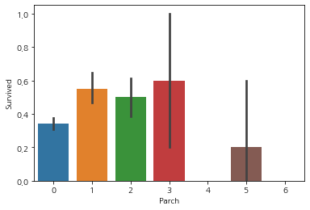

```python
sns.barplot(x="Parch", y="Survived", data=df)
```

#### 5) Embarked와 Survived의 관계

-> C에서 탑승한 승객이 생존한 사람이 많았다.

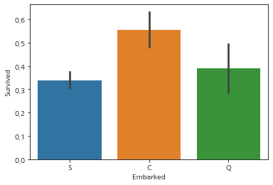

```python
sns.barplot(x="Embarked", y="Survived", data=df)
```

#### 상관관계를 구한다.

```python
corr=df.corr()
corr
```

|  | Survived | Pclass | Age | SibSp | Parch | Fare |
| --- | --- | --- | --- | --- | --- | --- |
| Survived | 1.000000 | -0.338481 | -0.070657 | -0.035322 | 0.081629 | 0.257307 |
| Pclass | -0.338481 | 1.000000 | -0.329727 | 0.083081 | 0.018443 | -0.549500 |
| Age | -0.070657 | -0.329727 | 1.000000 | -0.232440 | -0.180330 | 0.090632 |
| SibSp | -0.035322 | 0.083081 | -0.232440 | 1.000000 | 0.414838 | 0.159651 |
| Parch | 0.081629 | 0.018443 | -0.180330 | 0.414838 | 1.000000 | 0.216225 |
| Fare | 0.257307 | -0.549500 | 0.090632 | 0.159651 | 0.216225 | 1.000000 |

#### 상관관계 heatmap을 그려서 시각화한다.

-> 상관계수가 0에 가까우면 두 변수는 상관이 없다는 의미이다.

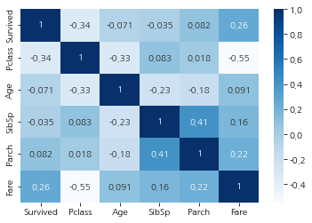

```python
sns.heatmap(corr, cmap="Blues", annot=True)
```

-> Pclass와 Fare는 음의 상관관계를 가진다. 즉, 좌석 등급의 숫자가 높을수록 비용이 낮아진다.

-> SibSp와 Parch는 양의 상관관계를 가진다. 즉, 형제, 배우자와 탑승한 사람이라면 자녀, 부모와 탑승했을 확률이 높다.

## 생존에 영향을 미치는 잠재 인자

1) 1등석에 탑승한 승객이 많이 생존했다.

2) 여성이 남성보다 많이 생존했다.

3) 함께 탑승한 형제, 배우자의 수가 생존에 영향을 미친다고 보기 어렵다.

4) 함께 탑승한 자녀, 부모의 수가 생존에 영향을 미친다고 보기 어렵다.

5) S, Q에서 탑승한 승객보다 C에서 탑승한 승객이 많이 생존했다.